# Risor ruber - Genetic analyses: relatedness and basic popgen

### Visualize relatedness

Kin structure - are individuals sharing a sponge more related than everyone else?

```r
#arranging df
rel_df2 <- rel_df2 %>%
  mutate(
    dyad_loc = case_when(
      same_sponge ~ "same group",          #same sponge
      same_reef   ~ "same reef",           #different sponge, same reef
      TRUE        ~ "different reefs"
    ),
    dyad_loc = factor(
      dyad_loc,
      levels = c("different reefs", "same reef", "same group")
    )
  )

means_df_rel <- rel_df2 %>%
  dplyr::group_by(dyad_loc) %>%
  dplyr::summarise(
    mean_wang = mean(Wang, na.rm = TRUE),
    .groups = "drop"
  )
```

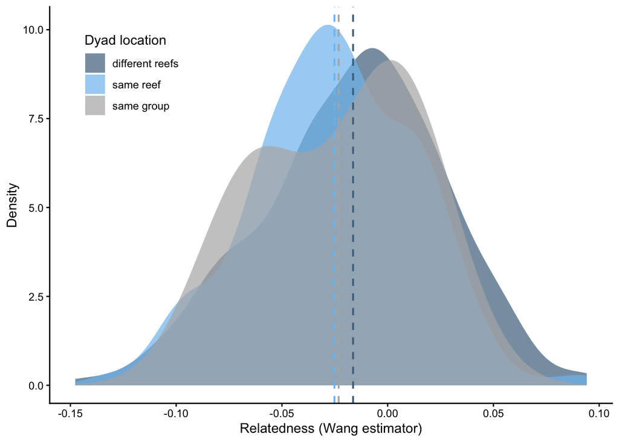

```r
#Figure 2A - Relatedness distribution

cols_rel <- c(
  "same group"       = "grey70",
  "same reef"       = "skyblue2",
  "different reefs" = "skyblue4")

ggplot(rel_df2, aes(x = Wang, fill = dyad_loc)) +
  geom_density(alpha = 0.7, adjust = 1.0, color = NA) +
  geom_vline(
    data = means_df_rel,
    aes(xintercept = mean_wang, colour = dyad_loc),
    linewidth = 0.7,
    linetype = "dashed",
    show.legend = FALSE
  ) +
  scale_fill_manual(
    values = cols_rel,
    name   = "Dyad location"
  ) +
  scale_colour_manual(
    values = cols_rel
  ) +
  labs(
    x = "Relatedness (Wang estimator)",
    y = "Density"
  ) +
  theme_classic() +
  theme(
    legend.position      = c(0.05, 0.95),
    legend.justification = c("left", "top"),
    legend.background    = element_rect(fill = "white", colour = NA)
  )
```

```r
ggsave(file.path(output_dir, "Fig_2A.pdf"), width = 5, height = 4, units = "in")
```

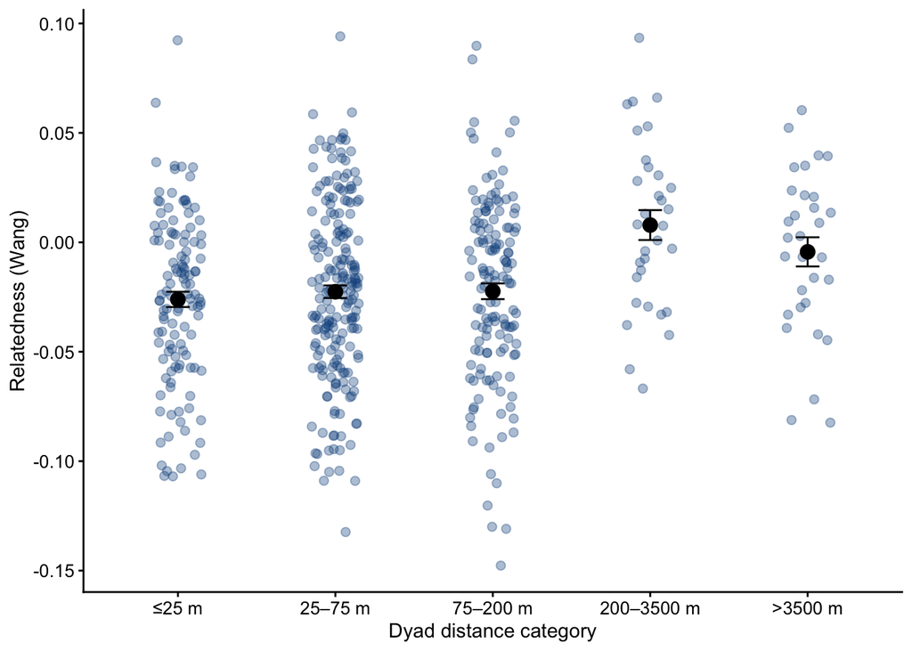

```r
#Figure 2B - Relatedness by distance class

#arranging df
rel_df2 <- rel_df2 %>%
  mutate(
    distance_km = if_else(!is.na(distance_km),
                          distance_km,
                          Distance_m / 1000),
    dist_bin = cut(
      distance_km,
      breaks = c(0, 0.025, 0.075, 0.2, 3.5, Inf),  # adjust if needed
      labels = c("≤25 m", "25–75 m", "75–200 m",
                 "200–3500 m", ">3500 m"),
      include.lowest = TRUE
    )
  )

bin_summ_rel <- rel_df2 %>%
  group_by(dist_bin) %>%
  summarise(
    n_dyads = n(),
    mean_wang = mean(Wang, na.rm = TRUE),
    se_wang   = sd(Wang, na.rm = TRUE) / sqrt(n()),
    .groups   = "drop"
  )

#plotting
ggplot(rel_df2, aes(x = dist_bin, y = Wang)) +
  # raw points
  geom_jitter(
    width  = 0.15,
    size   = 2,
    alpha  = 0.35,
    color  = "dodgerblue4"
  ) +
  #bin means
  geom_point(
    data        = bin_summ_rel,
    aes(x = dist_bin, y = mean_wang),
    inherit.aes = FALSE,
    size        = 3,
    color       = "black",
    fill        = "black",
    shape       = 21,
    stroke      = 0.8
  ) +
  #error bars
  geom_errorbar(
    data        = bin_summ_rel,
    aes(x = dist_bin,
        ymin = mean_wang - se_wang,
        ymax = mean_wang + se_wang),
    inherit.aes = FALSE,
    width       = 0.15,
    color       = "black"
  ) +
  labs(
    x = "Dyad distance category",
    y = "Relatedness (Wang)"
  ) +
  theme_classic() +
  theme(
    axis.text.x      = element_text(size = 10),
    axis.text.y      = element_text(size = 10),
    strip.background = element_blank(),
    legend.position  = "none"
  )
```

```r
ggsave(file.path(output_dir, "Fig_2B.pdf"), width = 5, height = 4, units = "in")
```

## 2. Pairwise genetic-distance analyses

Identity-by-state (IBS) is calculated from the population VCF and converted to genetic distance (`1 - IBS`). The GDS file is generated from the deposited VCF and is treated as a reproducible intermediate.

```r
# Convert the deposited VCF to GDS when needed, then open it for SNPRelate.The GDS file is a generated intermediate file
if (!file.exists(gds_out)) {
  snpgdsVCF2GDS(
    vcf.fn = vcf_all,
    out.fn = gds_out,
    method = "copy.num.of.ref"
  )
}
```

```
## Start file conversion from VCF to SNP GDS ...
## Method: dosage (0,1,2) of reference allele for all variant sites
## Number of samples: 44
## Parsing "../data/relatedness_popgen/pop_m5_r07_wl_biallelic_mac5.noHWEexcess_p1e4_LDpruned.vcf" ...
##  import 11332 variants.
## + genotype   { Bit2 44x11332, 121.7K } *
## Optimize the access efficiency ...
## Clean up the fragments of GDS file:
##     open the file '../outputs/pop_m5_r07_wl_biallelic_mac5.noHWEexcess_p1e4_LDpruned.vcf.gds' (191.8K)
##     # of fragments: 46
##     save to '../outputs/pop_m5_r07_wl_biallelic_mac5.noHWEexcess_p1e4_LDpruned.vcf.gds.tmp'
##     rename '../outputs/pop_m5_r07_wl_biallelic_mac5.noHWEexcess_p1e4_LDpruned.vcf.gds.tmp' (191.5K, reduced: 312B)
##     # of fragments: 20
```

```r
snpgdsSummary(gds_out)
```

```
## The file name: /Users/ingridbunholi/Desktop/Risor_popgen_paper/Submission_Files_Revision/Risor_Social-Life-History_data_dev/outputs/pop_m5_r07_wl_biallelic_mac5.noHWEexcess_p1e4_LDpruned.vcf.gds
## The total number of samples: 44
## The total number of SNPs: 11332
## SNP genotypes are stored in SNP-major mode (Sample X SNP).
```

```r
genofile_all <- snpgdsOpen(gds_out)

#Computing IBS (identical-by-state) to extract genetic distance
ibs    <- snpgdsIBS(genofile_all, autosome.only = FALSE)
```

```
## Identity-By-State (IBS) analysis on genotypes:
## Excluding 0 SNP (monomorphic: TRUE, MAF: NaN, missing rate: NaN)
##     # of samples: 44
##     # of SNPs: 11,332
##     using 1 thread
## IBS:    the sum of all selected genotypes (0,1,2) = 670260
## Wed Aug 12 14:08:29 2026    (internal increment: 65536)
## [..................................................]  0%, ETC: ---        [==================================================] 100%, completed, 0s
## Wed Aug 12 14:08:29 2026    Done.
```

```r
ibsnum <- snpgdsIBSNum(genofile_all, autosome.only = FALSE) #counts
```

```
## Identity-By-State (IBS) analysis on genotypes:
## Excluding 0 SNP (monomorphic: TRUE, MAF: NaN, missing rate: NaN)
##     # of samples: 44
##     # of SNPs: 11,332
##     using 1 thread
## IBS:    the sum of all selected genotypes (0,1,2) = 670260
## Wed Aug 12 14:08:29 2026    (internal increment: 65536)
## [..................................................]  0%, ETC: ---        [==================================================] 100%, completed, 0s
## Wed Aug 12 14:08:29 2026    Done.
```

```r
samples <- ibs$sample.id

#Obtaining genetic distance from IBS
IBS<- ibs$ibs
diag(IBS) <- 1

Nmat<- ibsnum$ibs0 + ibsnum$ibs1 + ibsnum$ibs2 #number of loci shared instead of proportion

D <- 1 - IBS #calculating genetic distance matrix
rownames(D) <- colnames(D) <- samples
rownames(IBS) <- colnames(IBS) <- samples
rownames(Nmat)   <- colnames(Nmat)   <- samples
```

### Assemble and model pairwise genetic distance

Genetic-distance dyads are matched to geographic and sponge metadata. Parallel models are fitted for the complete sample set and the filtered main-lineage set; their summaries and diagnostics provide the statistical results underlying Figure 2C-D.

```r
#Preparing data - cleaning IBS matrix
id_map <- meta_all %>%
  mutate(
    ind_id = str_match(id, ".*_(\\d+)(?:_d)?$")[,2] |> as.integer(),  # 52 from golden_52 or golden_52_d
    is_rep = str_detect(id, "_d$")
  ) %>%
  arrange(ind_id, is_rep) %>%                 #prefer non-_d if duplicated
  group_by(ind_id, sponge_id) %>% slice(1) %>% ungroup() %>%
  transmute(ind_id, sponge_id, sample = id)

keep_samples <- id_map$sample

IBS_clean <- IBS[keep_samples, keep_samples]

#Tidy IBS to one row per dyad
pairs_ibs <- IBS_clean %>%
  as.data.frame() %>%
  rownames_to_column("Individual1") %>%
  pivot_longer(-Individual1, names_to = "Individual2", values_to = "IBS")

#Tidy n_loci in the same way and join
pairs_n <- Nmat %>%
  as.data.frame() %>%
  rownames_to_column("Individual1") %>%
  pivot_longer(-Individual1, names_to = "Individual2", values_to = "n_loci")

pairs_ibs <- pairs_ibs %>%
  left_join(pairs_n, by = c("Individual1","Individual2")) %>%
  # keep one triangle only
  filter(Individual1 < Individual2) %>%
  mutate(
    gen_dist   = 1 - IBS,
    canon_pair = paste(pmin(Individual1, Individual2),
                       pmax(Individual1, Individual2), sep = "__")
  )

head(pairs_ibs)
```

```
## # A tibble: 6 × 6
##   Individual1 Individual2   IBS n_loci gen_dist canon_pair
##   <chr>       <chr>       <dbl>  <int>    <dbl> <chr>
## 1 golden_2    golden_3    0.934   6393   0.0656 golden_2__golden_3
## 2 golden_2    golden_21   0.924   6705   0.0761 golden_2__golden_21
## 3 golden_2    golden_32   0.430   6866   0.570  golden_2__golden_32
## 4 golden_2    golden_42   0.434   6824   0.566  golden_2__golden_42
## 5 golden_2    golden_44   0.440   6799   0.560  golden_2__golden_44
## 6 golden_2    golden_52   0.429   6803   0.571  golden_2__golden_52
```

```r
#Preparing data - pairwise geo distance
dist2 <- dist %>%
  dplyr::mutate(
    a_id = pmin(IN_ind_id, NEAR_ind_id),
    b_id = pmax(IN_ind_id, NEAR_ind_id),
    a_sp = if_else(IN_ind_id <= NEAR_ind_id, IN_sponge_id, NEAR_sponge_id),
    b_sp = if_else(IN_ind_id <= NEAR_ind_id, NEAR_sponge_id, IN_sponge_id)
  ) %>%
  distinct(a_id, b_id, a_sp, b_sp, .keep_all = TRUE) %>%
  left_join(id_map %>% rename(a_id = ind_id, a_sp = sponge_id, s1 = sample),
            by = c("a_id","a_sp")) %>%
  left_join(id_map %>% rename(b_id = ind_id, b_sp = sponge_id, s2 = sample),
            by = c("b_id","b_sp")) %>%
  dplyr::mutate(
    Individual1 = pmin(s1, s2),
    Individual2 = pmax(s1, s2),
    canon_pair  = paste(Individual1, Individual2, sep = "__")
  ) %>%
  dplyr::select(canon_pair, Individual1, Individual2, Distance_m) %>%
  distinct(canon_pair, .keep_all = TRUE)

dist2 <- dist2 %>%
  filter(!is.na(Individual1), !is.na(Individual2)) #filtering to only pairs with relatedness data

#Mege genetic distance and geogrpahic distance
df_merged <- pairs_ibs %>%
  inner_join(dist2, by = "canon_pair")

#write.csv(df_merged, "genetic_geographic_distance_fulldataset.csv")
```

```r
#Preparing data - gen dist + geo dist - full dataset and filtered dataset

diff_cluster <- c("golden_2","golden_3","golden_21","golden_64",
               "grunt_159","grunt_181","long_209","long_219","grunt_127", "golden_52_d", "golden_55_d")

lin_map <- tibble(sample = samples,
                  lineage = if_else(sample %in% diff_cluster, "out","main")) #mapping to which cluster each sample blong to

gd<- df_merged %>%
  transmute(Individual1 = std_id(Individual1.x),
            Individual2 = std_id(Individual2.x),
            gen_dist, n_loci, Distance_m)

#all samples - full dataset
gd_all <- gd %>%
  left_join(lin_map %>% rename(Individual1 = sample, lin1 = lineage), by = "Individual1") %>%
  left_join(lin_map %>% rename(Individual2 = sample, lin2 = lineage), by = "Individual2") %>%
  mutate(distance_km = Distance_m/1000,
         log_dist    = log1p(distance_km),
         i = factor(Individual1),
         j = factor(Individual2),
         w_std = n_loci/mean(n_loci, na.rm=TRUE)) #weigth loci

#adding env metrics from sponge for each individual in the pair
gd_sponge_all <- gd_all %>%
  left_join(sponge_meta %>%
              dplyr::select(id, sponge_id, S_width_cm, S_species, Reef) %>%
              rename(Individual1 = id,
                     sp1 = sponge_id,
                     size1 = S_width_cm,
                     species1 = S_species,
                     reef1 = Reef),
            by = "Individual1") %>%
  left_join(sponge_meta %>%
              dplyr::select(id, sponge_id, S_width_cm, S_species, Reef) %>%
              rename(Individual2 = id,
                     sp2 = sponge_id,
                     size2 = S_width_cm,
                     species2 = S_species,
                     reef2 = Reef),
            by = "Individual2") %>%
  mutate(
    same_sponge      = sp1 == sp2,
    same_reef        = reef1 == reef2,
    same_species     = species1 == species2,
    diff_sponge_sz   = abs(size1 - size2),
    log_dist_km      = log1p(distance_km),
    same_reef        = factor(same_reef),
    same_sponge      = factor(same_sponge),
    same_species     = factor(same_species),
    i                = factor(Individual1),
    j                = factor(Individual2)) #creating variables combining each indv from dyad

#only main cluster - filtered dataset
gd_main <- gd %>%
  left_join(lin_map %>% rename(Individual1 = sample, lin1 = lineage), by = "Individual1") %>%
  left_join(lin_map %>% rename(Individual2 = sample, lin2 = lineage), by = "Individual2") %>%
  filter(lin1=="main", lin2=="main") %>%
  mutate(distance_km = Distance_m/1000,
         log_dist    = log1p(distance_km),
         i = factor(Individual1),
         j = factor(Individual2),
         w_std = n_loci/mean(n_loci, na.rm=TRUE))

#adding env metrics from sponge for each individual in the pair
gd_sponge_main <- gd_main %>%
  left_join(sponge_meta %>%
              dplyr::select(id, sponge_id, S_width_cm, S_species, Reef) %>%
              rename(Individual1 = id,
                     sp1 = sponge_id,
                     size1 = S_width_cm,
                     species1 = S_species,
                     reef1 = Reef),
            by = "Individual1") %>%
  left_join(sponge_meta %>%
              dplyr::select(id, sponge_id, S_width_cm, S_species, Reef) %>%
              rename(Individual2 = id,
                     sp2 = sponge_id,
                     size2 = S_width_cm,
                     species2 = S_species,
                     reef2 = Reef),
            by = "Individual2") %>%
  mutate(
    same_sponge      = sp1 == sp2,
    same_reef        = reef1 == reef2,
    same_species     = species1 == species2,
    diff_sponge_sz   = abs(size1 - size2),
    log_dist_km      = log1p(distance_km),
    same_reef        = factor(same_reef),
    same_sponge      = factor(same_sponge),
    same_species     = factor(same_species),
    i                = factor(Individual1),
    j                = factor(Individual2))#creating variables combining each indv from dyad
```